# Assignment 2

Justine Lang

2023-03-29

```r
knitr::opts_chunk$set(echo = TRUE, warning = FALSE, message = FALSE)

library(readxl)
library(tidyverse)
library(kableExtra)
library(ggplot2)
library(formattable)
library(here)
library(janitor)
library(cowplot)
```

```r
#Read in plot xlsx data for each plot
p1<-read_csv(here("data", "Plot1.csv"))
# head(p1)

p2<-read_csv(here("data","Plot2.csv"))
# head(p2)

p3<-read_csv(here("data", "Plot3.csv"))
# head(p3)
```

```r
###read in 2023 data

p1_23 <-read_csv(here("data", "Plot1_2023.csv"))
# head(p1_23)

p2_23 <-read_csv(here("data","Plot2_2023.csv"))
# head(p2_23)

p3_23 <-read_csv(here("data", "Plot3_2023.csv"))
# head(p3_23)
```

### 1 & 2) Calculate Aboveground Biomass

```r
#parameters for Jenkins:
b0_j<--0.7152
b1_j<-1.7029
```

**2019**

```r
#Calculate aboveground biomass per tree (log is ln in R)
p1$bm_jenkins<-exp(b0_j+b1_j*log(p1$dbh))

p2$bm_jenkins<-exp(b0_j+b1_j*log(p2$dbh))

p3$bm_jenkins<-exp(b0_j+b1_j*log(p3$dbh))
```

```r
#parameters for KC:
b1_kc<-0.068
b2_kc<-2.569
```

```r
#Calculate aboveground biomass per tree
p1$bm_kc<-b1_kc*(p1$dbh^b2_kc)

p2$bm_kc<-b1_kc*(p2$dbh^b2_kc)

p3$bm_kc<-b1_kc*(p3$dbh^b2_kc)
```

```r
p1$plot <- 1

p2$plot <- 2

p3$plot <- 3
```

```r
all_plots <- p1 %>%
  full_join(p2) %>%
  full_join(p3)
```

```r
allplots_bm <- all_plots %>%
  select(plot, treeID, bm_jenkins, bm_kc) %>%
  kable(col.names = c("Plot", "Tree ID", "Biomass Jenkins (kg)", "Biomass KC (kg)"),
        caption = "Table 1: Biomass (2019)") %>%
  kable_classic(position = "center")

allplots_bm
```

Table 1: Biomass (2019)

| Plot | Tree ID | Biomass Jenkins (kg) | Biomass KC (kg) |
| --- | --- | --- | --- |
| 1 | 3 | 115.08434 | 257.24526 |
| 1 | 4 | 235.38564 | 757.12308 |
| 1 | 5 | 76.94715 | 140.15475 |
| 1 | 6 | 209.36114 | 634.45802 |
| 1 | 7 | 93.03581 | 186.63954 |
| 1 | 8 | 207.33375 | 625.21219 |
| 1 | 9 | 97.43835 | 200.12257 |
| 1 | 10 | 130.56402 | 311.19301 |
| 1 | 11 | 72.30295 | 127.59111 |
| 1 | 12 | 70.99801 | 124.13312 |
| 1 | 13 | 141.61589 | 351.77592 |
| 1 | 14 | 102.68037 | 216.58486 |
| 1 | 15 | 50.91006 | 75.15904 |
| 1 | 16 | 202.30097 | 602.45908 |
| 1 | 17 | 84.48451 | 161.37409 |
| 1 | 18 | 31.30797 | 36.09455 |
| 1 | 19 | 52.62165 | 79.00344 |
| 1 | 20 | 198.31156 | 584.62617 |
| 1 | 21 | 151.25514 | 388.51641 |
| 1 | 22 | 108.80939 | 236.38130 |
| 1 | 23 | 172.24834 | 472.67465 |
| 1 | 24 | 218.58488 | 677.09567 |
| 1 | 25 | 213.44031 | 653.19906 |
| 1 | 26 | 261.54146 | 887.56676 |
| 1 | 27 | 229.02522 | 726.47244 |
| 1 | 28 | 193.37102 | 562.79343 |
| 1 | 29 | 66.50833 | 112.48338 |
| 1 | 30 | 78.29592 | 143.87742 |
| 1 | 31 | 213.44031 | 653.19906 |
| 1 | 32 | 116.67571 | 262.63042 |

[output cut: 64 more lines]

**2023**

```r
#Calculate aboveground biomass per tree (log is ln in R)
p1_23$bm_jenkins<-exp(b0_j+b1_j*log(p1_23$dbh_cm))

p2_23$bm_jenkins<-exp(b0_j+b1_j*log(p2_23$dbh_cm))

p3_23$bm_jenkins<-exp(b0_j+b1_j*log(p3_23$dbh_cm))
```

```r
#Calculate aboveground biomass per tree
p1_23$bm_kc<-b1_kc*(p1_23$dbh_cm^b2_kc)

p2_23$bm_kc<-b1_kc*(p2_23$dbh_cm^b2_kc)

p3_23$bm_kc<-b1_kc*(p3_23$dbh_cm^b2_kc)
```

```r
p1_23$plot <- 1

p2_23$plot <- 2

p3_23$plot <- 3
```

```r
all_plots23 <- p1_23 %>%
  full_join(p2_23) %>%
  full_join(p3_23)
```

```r
allplots_bm23 <- all_plots23 %>%
  select(plot, treeID, bm_jenkins, bm_kc) %>%
  kable(col.names = c("Plot", "Tree ID", "Biomass Jenkins (kg)", "Biomass KC (kg)"),
        caption = "Table 2: Biomass (2023)") %>%
  kable_classic(position = "center")

allplots_bm23
```

Table 2: Biomass (2023)

| Plot | Tree ID | Biomass Jenkins (kg) | Biomass KC (kg) |
| --- | --- | --- | --- |
| 1 | 1 | 1698.36226 | 14925.3847 |
| 1 | 2 | 1040.57205 | 7127.8396 |
| 1 | 3 | 2483.46699 | 26478.1329 |
| 1 | 4 | 851.46054 | 5266.8032 |
| 1 | 5 | 762.84168 | 4462.1205 |
| 1 | 6 | 1042.54170 | 7148.2034 |
| 1 | 7 | 382.44466 | 1574.5732 |
| 1 | 8 | 382.44466 | 1574.5732 |
| 1 | 9 | 2208.17769 | 22177.4616 |
| 1 | 10 | 160.24422 | 423.8707 |
| 1 | 11 | 117.47478 | 265.3486 |
| 1 | 12 | 521.68260 | 2515.2403 |
| 1 | 13 | 284.19982 | 1006.0889 |
| 1 | 14 | 382.44466 | 1574.5732 |
| 1 | 15 | 1971.94081 | 18697.2989 |
| 1 | 16 | 851.46054 | 5266.8032 |
| 1 | 17 | 295.81897 | 1068.7826 |
| 1 | 18 | 1352.93161 | 10591.1769 |
| 1 | 19 | 851.46054 | 5266.8032 |
| 1 | 20 | 944.06104 | 6154.4059 |
| 1 | 21 | 833.41586 | 5099.3276 |
| 1 | 22 | 1352.93161 | 10591.1769 |
| 1 | 23 | 331.82026 | 1270.9656 |
| 1 | 24 | 851.46054 | 5266.8032 |
| 1 | 25 | 1140.92767 | 8189.9425 |
| 1 | 26 | 797.80663 | 4774.2327 |
| 1 | 27 | 851.46054 | 5266.8032 |
| 1 | 28 | 1331.06315 | 10333.9787 |
| 1 | 29 | 1245.06661 | 9343.4854 |
| 1 | 30 | 2128.20785 | 20977.0324 |
| 1 | 31 | 678.28160 | 3737.3673 |
| 1 | 32 | 1140.92767 | 8189.9425 |
| 1 | 33 | 492.41822 | 2305.4485 |
| 1 | 34 | 888.02705 | 5611.7291 |
| 1 | 35 | 1060.33763 | 7333.0771 |
| 1 | 36 | 661.86391 | 3601.7389 |
| 1 | 37 | 1202.96079 | 8870.9208 |
| 1 | 38 | 597.86447 | 3089.4653 |
| 1 | 39 | 1140.92767 | 8189.9425 |
| 1 | 40 | 422.33976 | 1828.8312 |
| 2 | 1 | 121.50380 | 279.1969 |
| 2 | 2 | 90.14761 | 177.9680 |
| 2 | 3 | 129.72927 | 308.1964 |
| 2 | 4 | 133.92509 | 323.3571 |
| 2 | 5 | 261.54146 | 887.5668 |
| 2 | 6 | 49.22190 | 71.4311 |
| 2 | 7 | 447.05607 | 1992.6736 |
| 2 | 8 | 298.75373 | 1084.8189 |
| 2 | 9 | 141.61589 | 351.7759 |
| 2 | 10 | 300.52032 | 1094.5107 |
| 2 | 11 | 313.60635 | 1167.2013 |
| 2 | 12 | 492.41822 | 2305.4485 |
| 2 | 13 | 597.86447 | 3089.4653 |
| 2 | 14 | 121.50380 | 279.1969 |
| 2 | 15 | 239.66580 | 777.9881 |
| 2 | 16 | 143.34897 | 358.2906 |
| 2 | 17 | 296.99144 | 1075.1796 |
| 3 | 1 | 3432.62227 | 43146.7504 |
| 3 | 2 | 2208.17769 | 22177.4616 |
| 3 | 3 | 1535.44426 | 12819.0058 |
| 3 | 4 | 521.68260 | 2515.2403 |
| 3 | 5 | 2075.57275 | 20199.3021 |
| 3 | 6 | 3714.34375 | 48598.9531 |
| 3 | 7 | 4404.53255 | 62847.8291 |
| 3 | 8 | 4953.63721 | 75035.3308 |
| 3 | 9 | 5142.55468 | 79394.0074 |

### 3) Plot Aboveground Biomass

**2019**

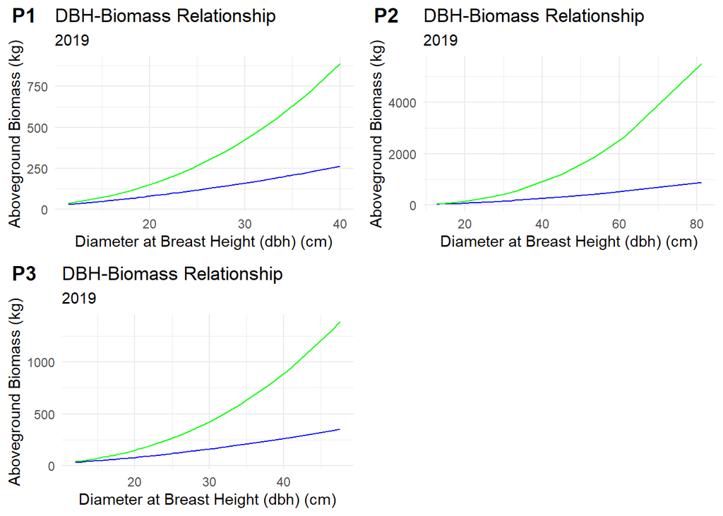

Figure 1: DBH-biomass relationships for three different plots in 2019, based on Jenkins et al. (2004) (blue line) and Karlik and Chojnacky (2014) (green line) allometric equations.

```r
p1_gg <- ggplot() +
  geom_line(data = p1, aes(x = dbh, y = bm_jenkins), color = "blue") +
  geom_line(data = p1, aes(x = dbh, y = bm_kc), color = "green") +
  theme_minimal() +
  labs(x = "Diameter at Breast Height (dbh) (cm)",
        y = "Aboveground Biomass (kg)",
        title = "DBH-Biomass Relationship",
        subtitle = "2019")

# p1_gg

p2_gg <- ggplot() +
  geom_line(data = p2, aes(x = dbh, y = bm_jenkins), color = "blue") +
  geom_line(data = p2, aes(x = dbh, y = bm_kc), color = "green") +
  theme_minimal() +
  labs(x = "Diameter at Breast Height (dbh) (cm)",
        y = "Aboveground Biomass (kg)",
        title = "DBH-Biomass Relationship",
        subtitle = "2019")

# p2_gg

p3_gg <- ggplot() +
  geom_line(data = p3, aes(x = dbh, y = bm_jenkins), color = "blue") +
  geom_line(data = p3, aes(x = dbh, y = bm_kc), color = "green") +
  theme_minimal() +
  labs(x = "Diameter at Breast Height (dbh) (cm)",
        y = "Aboveground Biomass (kg)",
        title = "DBH-Biomass Relationship",
        subtitle = "2019")

# p3_gg

plot_grid(p1_gg, p2_gg, p3_gg, labels = c('P1', 'P2', 'P3'))
```

**2023**

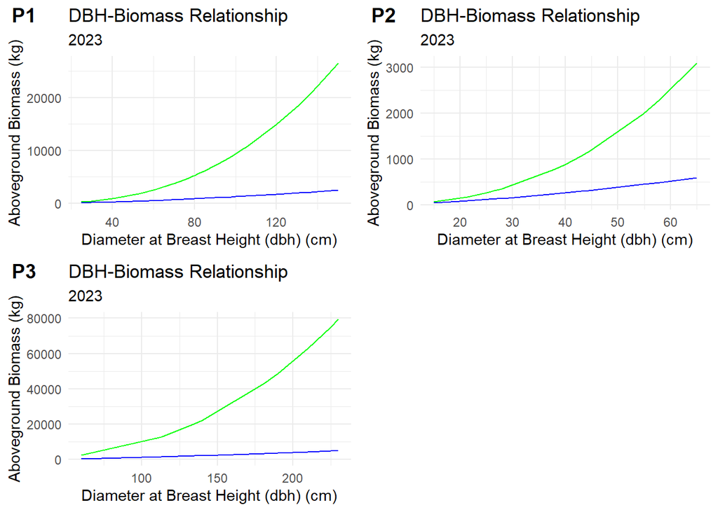

Figure 2: DBH-biomass relationships for three different plots in 2023, based on Jenkins et al. (2004) (blue line) and Karlik and Chojnacky (2014) (green line) allometric equations.

```r
p1_gg23 <- ggplot() +
  geom_line(data = p1_23, aes(x = dbh_cm, y = bm_jenkins), color = "blue") +
  geom_line(data = p1_23, aes(x = dbh_cm, y = bm_kc), color = "green") +
  theme_minimal() +
  labs(x = "Diameter at Breast Height (dbh) (cm)",
        y = "Aboveground Biomass (kg)",
        title = "DBH-Biomass Relationship",
        subtitle = "2023")

# p1_gg23

p2_gg23 <- ggplot() +
  geom_line(data = p2_23, aes(x = dbh_cm, y = bm_jenkins), color = "blue") +
  geom_line(data = p2_23, aes(x = dbh_cm, y = bm_kc), color = "green") +
  theme_minimal() +
  labs(x = "Diameter at Breast Height (dbh) (cm)",
        y = "Aboveground Biomass (kg)",
        title = "DBH-Biomass Relationship",
        subtitle = "2023")

# p2_gg23

p3_gg23 <- ggplot() +
  geom_line(data = p3_23, aes(x = dbh_cm, y = bm_jenkins), color = "blue") +
  geom_line(data = p3_23, aes(x = dbh_cm, y = bm_kc), color = "green") +
  theme_minimal() +
  labs(x = "Diameter at Breast Height (dbh) (cm)",
        y = "Aboveground Biomass (kg)",
        title = "DBH-Biomass Relationship",
        subtitle = "2023")

# p3_gg23

plot_grid(p1_gg23, p2_gg23, p3_gg23, labels = c('P1', 'P2', 'P3'))
```

### 4) Biomass per Plot

**2019**

```r
#Biomass and carbon:
totalplotarea<-(50*25)*0.0001 #50 meter by 25 meter, converted to hectares
carboncontent<-.4585 #The carbon content of branch/stem material combined ranged from 45.06% to 46.70%, with a mean of 45.85% (SE 0.276%); mean can be used to convert biomass to carbon storage
```

```r
#Calculate aboveground biomass per plot for Karlik_Chojnacky
p1_bm_kc<-sum(p1$bm_kc)
p2_bm_kc<-sum(p2$bm_kc)
p3_bm_kc<-sum(p3$bm_kc)

all_biomass <- rbind(p1_bm_kc, p2_bm_kc, p3_bm_kc) %>%
  kable(col.names = c("Biomass (kg)"),
        caption = "Table 3: Biomass per Plot (2019)") %>%
  kable_classic(position = "center")

all_biomass
```

Table 3: Biomass per Plot (2019)

|  | Biomass (kg) |
| --- | --- |
| p1_bm_kc | 11247.84 |
| p2_bm_kc | 18077.71 |
| p3_bm_kc | 14550.54 |

```r
###calculate biomass per plot per square meter based on total size of the plot

### total plot area is 0.125 hectares, which is 1250 square meters (1 ha = 10,000 m^2)

p1_bm_kc_sq <- p1_bm_kc/1250

p2_bm_kc_sq <- p2_bm_kc/1250

p3_bm_kc_sq <- p3_bm_kc/1250

all_biomass_sq <- rbind(p1_bm_kc_sq, p2_bm_kc_sq, p3_bm_kc_sq) %>%
  kable(col.names = c("Biomass/m^2"),
        caption = "Table 4: Biomass per Square Meter (2019)") %>%
  kable_classic(position = "center")

all_biomass_sq
```

Table 4: Biomass per Square Meter (2019)

|  | Biomass/m^2 |
| --- | --- |
| p1_bm_kc_sq | 8.998272 |
| p2_bm_kc_sq | 14.462164 |
| p3_bm_kc_sq | 11.640428 |

**2023**

```r
#Calculate aboveground biomass per plot for Karlik_Chojnacky
p1_bm_kc23 <- sum(p1_23$bm_kc)
p2_bm_kc23 <- sum(p2_23$bm_kc)
p3_bm_kc23 <- sum(p3_23$bm_kc)

all_biomass23 <- rbind(p1_bm_kc23, p2_bm_kc23, p3_bm_kc23) %>%
  kable(col.names = c("Biomass (kg)"),
        caption = "Table 5: Biomass per Plot (2023)") %>%
  kable_classic(position = "center")

all_biomass23
```

Table 5: Biomass per Plot (2023)

|  | Biomass (kg) |
| --- | --- |
| p1_bm_kc23 | 277437.70 |
| p2_bm_kc23 | 15624.27 |
| p3_bm_kc23 | 366733.88 |

```r
###calculate biomass per plot per square meter based on total size of the plot

p1_bm_kc_sq23 <- p1_bm_kc23/1250

p2_bm_kc_sq23 <- p2_bm_kc23/1250

p3_bm_kc_sq23 <- p3_bm_kc23/1250

all_biomass_sq23 <- rbind(p1_bm_kc_sq23, p2_bm_kc_sq23, p3_bm_kc_sq23) %>%
  kable(col.names = c("biomass/m^2"),
        caption = "Table 6: Biomass per Square Meter (2023)") %>%
  kable_classic(position = "center")

all_biomass_sq23
```

Table 6: Biomass per Square Meter (2023)

|  | biomass/m^2 |
| --- | --- |
| p1_bm_kc_sq23 | 221.95016 |
| p2_bm_kc_sq23 | 12.49941 |
| p3_bm_kc_sq23 | 293.38710 |

### Carbon per Plot

**2019**

```r
#Convert estimate to tree carbon per hectare (hint: use 'carboncontent' variable to convert biomass estimates to carbon; then use 'totalplotarea' in hectares variable to convert to carbon per hectare)
#make a table of the output

###(bm*0.4585)/(1250m2 * 0.0001) to get carbon per hectare
### in other words, (bm*carboncontent)/totalplotarea

p1_carbon <- p1_bm_kc*carboncontent
p2_carbon <- p2_bm_kc*carboncontent
p3_carbon <- p3_bm_kc*carboncontent

p1_carbon_ha <- p1_carbon/totalplotarea
p2_carbon_ha <- p2_carbon/totalplotarea
p3_carbon_ha <- p3_carbon/totalplotarea

all_carbon_ha <- rbind(p1_carbon_ha, p2_carbon_ha, p3_carbon_ha) %>%
  kable(col.names = c("carbon/ha"),
        caption = "Table 7: Tree Carbon per Hectare (2019)") %>%
  kable_classic(position = "center")

all_carbon_ha
```

Table 7: Tree Carbon per Hectare (2019)

|  | carbon/ha |
| --- | --- |
| p1_carbon_ha | 41257.08 |
| p2_carbon_ha | 66309.02 |
| p3_carbon_ha | 53371.36 |

**2023**

```r
p1_carbon23 <- p1_bm_kc23*carboncontent
p2_carbon23 <- p2_bm_kc23*carboncontent
p3_carbon23 <- p3_bm_kc23*carboncontent

p1_carbon_ha23 <- p1_carbon23/totalplotarea
p2_carbon_ha23 <- p2_carbon23/totalplotarea
p3_carbon_ha23 <- p3_carbon23/totalplotarea

all_carbon_ha23 <- rbind(p1_carbon_ha23, p2_carbon_ha23, p3_carbon_ha23) %>%
  kable(col.names = c("carbon/ha"),
        caption = "Table 8: Tree Carbon per Hectare (2023)") %>%
  kable_classic(position = "center")

all_carbon_ha23
```

Table 8: Tree Carbon per Hectare (2023)

|  | carbon/ha |
| --- | --- |
| p1_carbon_ha23 | 1017641.47 |
| p2_carbon_ha23 | 57309.81 |
| p3_carbon_ha23 | 1345179.87 |

### 5) Sources of Error and Uncertainty

**Briefly discuss the major sources of uncertainty and error in your estimate of carbon in blue oak woodlands at Sedgwick Reserve, and how you might reduce the uncertainty in that estimate.**

There are sources of uncertainty that lie with the KC biomass equation itself. In their paper, they indicated that the study was the first of its kind for blue oak in California and that they were limited by a small sample size. The Jenkins biomass equation indicates that the estimated biomass and resulting estimated carbon could have been much smaller, although the Jenkins equation involves some assumptions (i.e., that the parameters for blue oaks were equivalent to those for the juniper/oak/mesquite category), which may have contributed to its own sources of error and uncertainty. Relatedly, while the KC parameters were based on blue oak, we also applied them to California live oak, which may not have been exactly equivalent to blue oak.

Karlik and Chojnacky recommended duplicating their study with a larger sample size of smaller and larger oaks throughout more sites in California, plus additional carbon sampling, to improve their biomass and carbon estimations. Those of us that gathered the 2023 data also could have been more careful with our sampling technique, especially in the plots where the slope was steep and the trees were leaning, to reduce the initial sampling errors.